# A Study on Fuel Efficient Transmission Type

thenuv

31 July 2018

## Executive Summary

The convenience of automatic transmission in cars leads to the question of fuel inefficiency. To provide an insight on if its the case, we study the dataset *mtcars* to explore the possible outcomes. Linear Regression model is used for this Analysis.

If we measure the fuel efficiency with type of transmission alone(Automatic/manual), then manual seems to be more efficient. But while including other correlated variables, we could infer Automatic is as efficient as manual and infact better to a smaller extend.

## Data Processing

```r
suppressMessages(library(ggplot2))
suppressMessages(library(car))
data("mtcars")
mtcars$am<-factor(mtcars$am)
levels(mtcars$am)<-c("automatic", "manual")
```

We use the mtcars dataset collected by Motor trend in 1974. There are 32 observations and 11 variables. Variable *am* represents the transmission type. we convert them into factor and name accordingly. Following Variables are used in the Analysis

- **mpg** Miles/(US) gallon
- **cyl** Number of cylinders
- **wt** Weight (1000 lbs)
- **am** Transmission (0 = automatic, 1 = manual)
- **disp** Displacement (cu.in.)

## Exploratory Ananylsis

```r
summary(mtcars$mpg[mtcars$am=="automatic"])
```

```
##    Min. 1st Qu.  Median    Mean 3rd Qu.    Max.
##   10.40   14.95   17.30   17.15   19.20   24.40
```

```r
summary(mtcars$mpg[mtcars$am=="manual"])
```

```
##    Min. 1st Qu.  Median    Mean 3rd Qu.    Max.
##   15.00   21.00   22.80   24.39   30.40   33.90
```

```r
m <- lm(mpg ~ am -1, mtcars)
summary(m)$coef
```

```
##             Estimate Std. Error  t value     Pr(>|t|)
## amautomatic 17.14737   1.124603 15.24749 1.133983e-15
## ammanual    24.39231   1.359578 17.94109 1.376283e-17
```

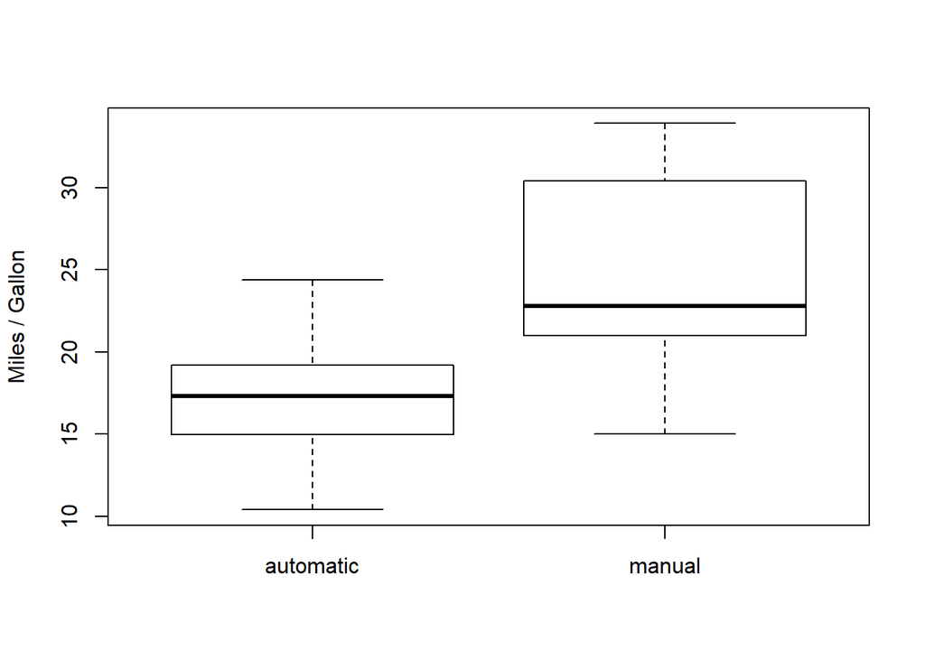

```r
boxplot(mpg ~ am, data=mtcars, ylab = "Miles / Gallon")
```

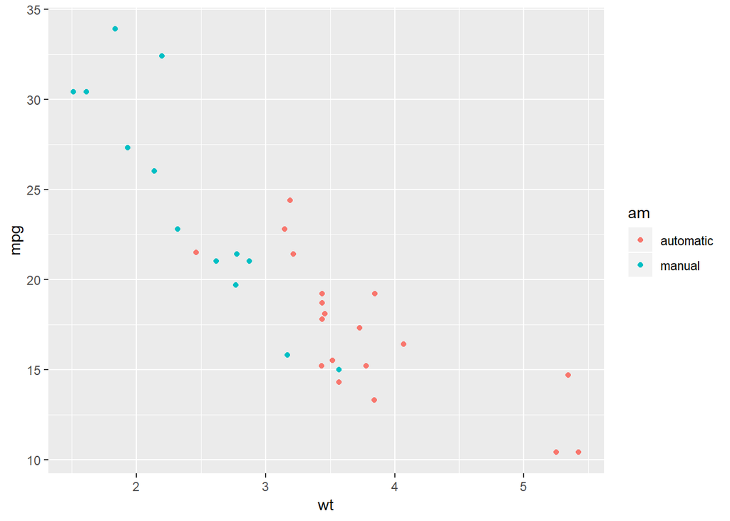

```r
qplot(x=wt, y=mpg, color=am,  data=mtcars)
```

```r
t.test(mtcars$mpg[mtcars$am=="automatic"], mtcars$mpg[mtcars$am=="manual"])$p.value
```

```
## [1] 0.001373638
```

The mean of miles per gallon looks higher for manual when its looked as the only variable. However we could observe from the scatter plot, as the other variables like weight and cylinders increase there is not much difference due between automatic and manual. From the t test pvalue its evident there is significance on transmission type with the millege. We reject the null hypotheis and look for more details.

## Model the Analysis

```r
fit <- lm(mpg ~ ., data = mtcars)       # Fit a model with all variables with mpg as outcome
vif(fit)        # Get the variable inflation factor
```

```
##       cyl      disp        hp      drat        wt      qsec        vs
## 15.373833 21.620241  9.832037  3.374620 15.164887  7.527958  4.965873
##        am      gear      carb
##  4.648487  5.357452  7.908747
```

```r
m1 <- lm (mpg ~ am, mtcars)             # Model m1 with mpg and Transmission type
m2 <- lm (mpg ~ am + wt , mtcars)       # Model m2 as m1 + variable weight
m3 <- lm (mpg ~ am + wt + cyl , mtcars) # Model m3 as m2 + variable cylinder
m4 <- lm (mpg ~ am + wt + cyl + disp, mtcars) # Model m4 as m3 + variable displacement

anova(m1, m2, m3, m4) # Compare Models
```

|  | Res.Df | RSS | Df | Sum of Sq | F | Pr(>F) |
| --- | --- | --- | --- | --- | --- | --- |
| 1 | 30 | 720.8966 | NA | NA | NA | NA |
| 2 | 29 | 278.3197 | 1 | 442.576902 | 63.4179367 | 1.469131e-08 |
| 3 | 28 | 191.0471 | 1 | 87.272637 | 12.5055115 | 1.487689e-03 |
| 4 | 27 | 188.4258 | 1 | 2.621246 | 0.3756049 | 5.450930e-01 |